# INFO 204 Assignment 1 Template - Data Science Job Locations

# Scraping Procedure

We start with defining a few key components (the required libraries, starting url, and key XPath/CSS selectors):

```r
library(rvest)
blog.url <- "https://www.westernunion.com/blog/jobs-in-demand/"
doc.url <- read_html(blog.url)

list.jobtitles <- html_nodes(doc.url, "#main > div.row.row-flex.post-single > div > div > div.row.post-data > div > div.post-content > h2")
raw.data <- html_text(list.jobtitles)
clean.jobtitles.data <- gsub("[\n]", "", raw.data)
clean.jobtitles.data
```

```
## [1] "Software Engineers and Developers" "Mechanical & Civil Engineers"
## [3] "IT Analysts"                       "Accountants"
## [5] "Surveyors & Skilled Construction " "Teachers "
## [7] "Chefs "                            "Pharmacists "
## [9] "Psychologists"
```

However for the second part, we have to exclude other paragraphs.

```r
countries.selector <- "//*[@id='main']/div[2]/div/div/div[2]/div/div[3]/p[5]"
list.paragraphs <- html_nodes(doc.url, xpath=countries.selector)
raw.paragraphs.data <- html_text(list.paragraphs)
raw.paragraphs.data
```

```
## [1] "Countries in Demand: Belgium, Czech Republic, Denmark, Estonia, France, Germany, Greece, Ireland, Israel, Luxembourg, Netherlands, Russia, Slovak Republic, Sweden, United Kingdom, Canada, Mexico, United States, Brazil, Chile, Japan, Korea, Australia, New Zealand"
```

```r
countries.selector <- "//*[@id='main']/div[2]/div/div/div[2]/div/div[3]/p[9]"
list.paragraphs <- html_nodes(doc.url, xpath=countries.selector)
raw.paragraphs.data <- html_text(list.paragraphs)
raw.paragraphs.data
```

```
## [1] "Countries in Demand: Denmark, Belgium, Estonia, Norway, Switzerland, Turkey, Finland, Greece, Iceland, Netherlands, Russia, Slovak Republic, Spain, United Kingdom, Hungary, Luxembourg, Sweden, Germany, Ireland, Canada, Mexico, United States, Brazil, Chile, Australia, New Zealand "
```

We start with defining a few key components (the required libraries, starting url, and key XPath/CSS selectors):

```r
library(rvest)

search.url <- "https://www.seek.co.nz/jobs?keywords=%22data+science%22"
job.selector <- "//article[@data-automation='normalJob']" ## note: XPath selector!
title.selector <- "h1 a"
```

As, we’re going to be scraping multiple pages, and the source links will be scraped from our start document, we will need to use a session to keep track of the relevant details:

```r
doc <- html_session(search.url)
```

And now, we should retrieve our required list of advertised jobs:

```r
jobs <- html_nodes(doc, xpath=job.selector)
cat("Fetched", length(jobs), "results\n")
```

```
## Fetched 17 results
```

note that we used the `xpath` parameter of the `html_nodes()` function instead of using a normal CSS selector. This was due to the selection of by attribute status, which cannot be easily done using a CSS selector.

Having found the 17 jobs, we need to extract the required hyperlinks that lead us to the job description pages:

```r
job.links <- html_nodes(jobs, title.selector)
job.href <- html_attr(job.links, "href")
```

Now, we perform the iteration over the href attributes that we discovered, extract the relevant page elements, and add them into a results list (steps 2 a, b, and c in our previously defined workflow).

```r
location.selector <- "dl > dd:nth-child(4) > span > span > strong"
job.locations <- NULL ## a container for our results, starts off empty
for (job in job.href) {
  job.loc <- tryCatch({
    job.doc <- jump_to(doc, job)
    job.loc <- html_node(job.doc, location.selector)

    html_text(job.loc)
  }, error=function(e) NULL)

  ## add the next location to our results vector
  job.locations <- c(job.locations, job.loc)
}
job.locations
```

```
##  [1] "Canterbury" "Canterbury" "Auckland"   "Wellington" "Auckland"
##  [6] "Canterbury" "Canterbury" "Wellington" "Canterbury" "Auckland"
## [11] "Auckland"   "Auckland"   "Wellington" "Taranaki"   "Auckland"
## [16] "Auckland"   "Auckland"
```

Note the use of the `tryCatch()` function here - this is to handle any cases where following a link may produce an error (e.g., a 404 error for a broken link referring to a missing page).

# Analysis

Our `job.locations` vector is now complete, and should contain an entry for every job advertised. Now, we can create a tally of these locations and plot them using a suitable method (e.g., a bar plot):

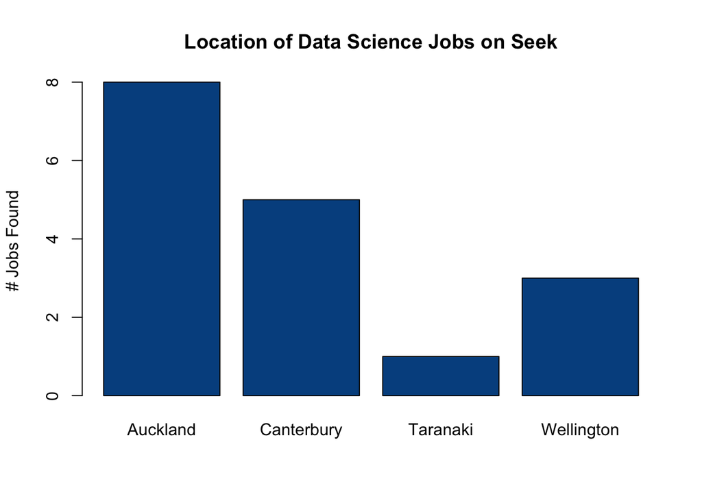

```r
tally <- table(job.locations)
barplot(tally, main="Location of Data Science Jobs on Seek", ylab="# Jobs Found", col="#00508f")
```

## Assumptions

The analysis here is rather simple - we have only really considered a single search for jobs on a single web site. To be more rigorous, we should examine multiple web sites, and maybe attempt to consider other terms often confused with or related to “data science” (e.g., “predictive analytics”, “data mining”, “machine learning”).